# REFUTES Funnel

Narrowing down citing works that contradict a Background Message

Published

August 18, 2026

# IAS

## Methodology

Every work discovered by the snowball search under a Background Message (BM) is put through a 3-level sieve, each level a **subset** of the one before it, counted as **distinct citing works per (assessment, km, bm)** — a work cited under two different BMs is two separate findings, not one, so per-BM counts sum to the assessment-wide total shown below.

1. **Snowball corpus** — every citing work discovered for that BM (the forward/citing direction of the snowball search).
2. **NLI REFUTES (certain)** — of those, works with at least one claim scored `label == "REFUTES"` with `uncertain == FALSE` by the zero-shot NLI model (Phase 1 — see TD_BM_NLI_approach).
3. **LLM-confirmed REFUTES** — of those, works where OpenRouter’s LLM review (Phase 2 — see TD_NLI_LLM_two_phase) independently agreed with the REFUTES verdict (`llm_agrees == TRUE`).

There is deliberately no further “+ sufficient evidence” level: Phase 2’s own verification logic forces its `llm_label` to `NOT_ENOUGH_INFO` whenever it judges the evidence insufficient, so an LLM verdict of REFUTES already *implies* sufficient evidence — a separate level here would always contain exactly the same works as level 3.

**Phase 2 (LLM verification) is a partial, ongoing process** — OpenRouter credit has run out mid-run at least once already, so level 3 below reflects only the pairs reviewed so far, not the full REFUTES-certain set from level 2. This number will grow as `llm_verification_parquet` gets more OpenRouter runs; re-render this report after a rerun rather than treating today’s snapshot as final.

```r
if (isTRUE(x$empty)) {
  cat("No data available yet for this assessment — the snowball, NLI, or LLM verification stage hasn't produced output here.\n\n")
  knitr::knit_exit()
}
```

## Overall numbers

```r
knitr::kable(
  x$funnel_overall,
  col.names = c("Level", "Description", "Distinct works")
)
```

| Level | Description | Distinct works |
| --- | --- | --- |
| level1 | Snowball corpus | 177357 |
| level2 | NLI REFUTES (certain) | 9327 |
| level3 | LLM-confirmed REFUTES | 704 |

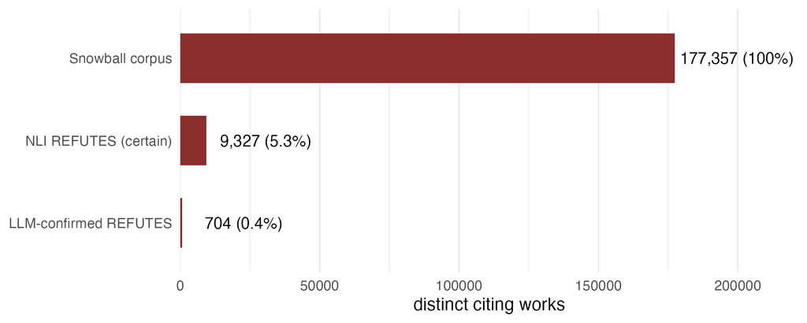

```r
if (length(fig_overall)) cat(sprintf("![](%s)\n\n", fig_overall))
```

## Per-BM numbers

```r
knitr::kable(
  x$funnel_by_bm,
  col.names = c(
    "KM", "BM", "Corpus", "NLI REFUTES", "LLM-confirmed",
    "% 2 of 1", "% 3 of 2"
  )
)
```

| KM | BM | Corpus | NLI REFUTES | LLM-confirmed | % 2 of 1 | % 3 of 2 |
| --- | --- | --- | --- | --- | --- | --- |
| KM-A1 | A1 | 7151 | 768 | 74 | 10.7 | 9.6 |
| KM-A2 | A2 | 9599 | 586 | 161 | 6.1 | 27.5 |
| KM-A2 | A3 | 7125 | 196 | 10 | 2.8 | 5.1 |
| KM-A3 | A4 | 9813 | 1499 | 127 | 15.3 | 8.5 |
| KM-A3 | A5 | 5444 | 109 | 20 | 2.0 | 18.3 |
| KM-A4 | A5 | 5444 | 109 | 0 | 2.0 | 0.0 |
| KM-A4 | A6 | 2943 | 64 | 0 | 2.2 | 0.0 |
| KM-A5 | A7 | 8613 | 101 | 5 | 1.2 | 5.0 |
| KM-A5 | A8 | 2401 | 126 | 8 | 5.2 | 6.3 |
| KM-B1 | B11 | 5302 | 113 | 10 | 2.1 | 8.8 |
| KM-B1 | B12 | 5179 | 65 | 5 | 1.3 | 7.7 |
| KM-B1 | B14 | 6085 | 381 | 62 | 6.3 | 16.3 |
| KM-B1 | B9 | 4608 | 418 | 18 | 9.1 | 4.3 |
| KM-B2 | B10 | 929 | 25 | 2 | 2.7 | 8.0 |
| KM-B3 | B11 | 5302 | 113 | 0 | 2.1 | 0.0 |
| KM-B3 | B12 | 5179 | 65 | 0 | 1.3 | 0.0 |
| KM-B3 | B14 | 6085 | 381 | 0 | 6.3 | 0.0 |
| KM-B3 | B9 | 4608 | 418 | 0 | 9.1 | 0.0 |
| KM-B4 | B10 | 929 | 25 | 0 | 2.7 | 0.0 |
| KM-B4 | B13 | 5228 | 93 | 7 | 1.8 | 7.5 |
| KM-B4 | B14 | 6085 | 381 | 0 | 6.3 | 0.0 |
| KM-C1 | C15 | 602 | 35 | 20 | 5.8 | 57.1 |
| KM-C1 | C16 | 2203 | 107 | 19 | 4.9 | 17.8 |
| KM-C1 | C17 | 2580 | 169 | 7 | 6.6 | 4.1 |
| KM-C1 | C18 | 1823 | 36 | 1 | 2.0 | 2.8 |
| KM-C1 | C22 | 2359 | 350 | 19 | 14.8 | 5.4 |
| KM-C1 | C23 | 2413 | 29 | 4 | 1.2 | 13.8 |
| KM-C2 | C15 | 602 | 35 | 0 | 5.8 | 0.0 |
| KM-C2 | C17 | 2580 | 169 | 0 | 6.6 | 0.0 |
| KM-C2 | C18 | 1823 | 36 | 0 | 2.0 | 0.0 |
| KM-C3 | C19 | 2170 | 109 | 14 | 5.0 | 12.8 |
| KM-C4 | C20 | 1576 | 50 | 6 | 3.2 | 12.0 |
| KM-C5 | C21 | 3676 | 483 | 29 | 13.1 | 6.0 |
| KM-C6 | C23 | 2413 | 29 | 0 | 1.2 | 0.0 |
| KM-C6 | C24 | 884 | 67 | 14 | 7.6 | 20.9 |
| KM-D1 | D25 | 1768 | 17 | 0 | 1.0 | 0.0 |
| KM-D2 | D26 | 2500 | 70 | 10 | 2.8 | 14.3 |
| KM-D2 | D30 | 2739 | 4 | 0 | 0.1 | 0.0 |
| KM-D3 | D27 | 1768 | 5 | 0 | 0.3 | 0.0 |
| KM-D3 | D28 | 1098 | 29 | 3 | 2.6 | 10.3 |
| KM-D4 | D26 | 2500 | 69 | 0 | 2.8 | 0.0 |
| KM-D4 | D33 | 1423 | 30 | 4 | 2.1 | 13.3 |
| KM-D5 | D31 | 2903 | 168 | 6 | 5.8 | 3.6 |
| KM-D5 | D32 | 3802 | 257 | 32 | 6.8 | 12.5 |
| KM-D6 | D29 | 3170 | 227 | 7 | 7.2 | 3.1 |
| KM-D6 | D31 | 2903 | 168 | 0 | 5.8 | 0.0 |
| KM-D6 | D32 | 3802 | 256 | 0 | 6.7 | 0.0 |
| KM-D7 | D32 | 3802 | 257 | 0 | 6.8 | 0.0 |
| KM-D7 | D33 | 1423 | 30 | 0 | 2.1 | 0.0 |

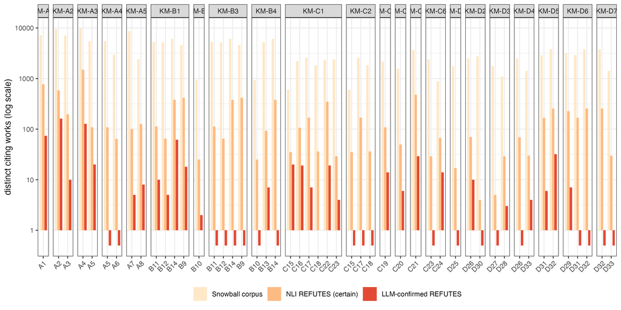

```r
if (length(fig_by_bm)) cat(sprintf("![](%s)\n\n", fig_by_bm))
```

## Level 3: LLM-confirmed REFUTES

Every citing work where the LLM’s own independent review agreed with NLI’s REFUTES verdict (and, by construction, judged the evidence for it sufficient — see Methodology). Use the BM dropdown in the filter row below the header to narrow to one Background Message.

```r
if (length(table_l3)) {
  cat(sprintf(
    '<iframe src="%s" width="100%%" height="800px" style="border:none;"></iframe>\n\n',
    table_l3
  ))
}
```

[interactive chart not shown]